# NYPD Shooting Incident Project

Zachary Kekoa

2023-10-09

## Introduction

This dataset was pulled from Kaggle, but was originally from Data.gov and is provided by the NYPD every quarter. This dataset includes shooting incident data throughout the New York City metro area from December 31st 2005 – December 31st, 2022and includes 27,312 observations. The 14 variables that will be used in this analysis are incident key (a unique number identifying each incident), occur date (the date when the shooting occurred), boro (the name of the borough where the shooting occurred), precinct (the number of the NYPD precinct district the shooting fell into), jurisdiction code (Jurisdiction responsible for arrest. The codes are 0(Patrol, 1(transit), and 2(housing)), statistical murder flag (whether the shooting was a murder), perp age group/sex/race (the age group, sex, and race of the perpetrator. Similarly for the victim. As well as latitude and longitude data.

## Import the Data

```r
library(ggplot2)
library(lubridate)
library(dplyr)
# leaflet and leaflet.extras are not a part of the COVID 19 data libraries and
# may need to be installed on your computer
library(leaflet)
library(leaflet.extras)
```

```r
nypd <- read.csv("https://data.cityofnewyork.us/api/views/833y-fsy8/rows.csv?accessType=DOWNLOAD", na.strings = c(""))

head(nypd)
```

```
##   INCIDENT_KEY OCCUR_DATE OCCUR_TIME     BORO LOC_OF_OCCUR_DESC PRECINCT
## 1    228798151 05/27/2021   21:30:00   QUEENS              <NA>      105
## 2    137471050 06/27/2014   17:40:00    BRONX              <NA>       40
## 3    147998800 11/21/2015   03:56:00   QUEENS              <NA>      108
## 4    146837977 10/09/2015   18:30:00    BRONX              <NA>       44
## 5     58921844 02/19/2009   22:58:00    BRONX              <NA>       47
## 6    219559682 10/21/2020   21:36:00 BROOKLYN              <NA>       81
##   JURISDICTION_CODE LOC_CLASSFCTN_DESC LOCATION_DESC STATISTICAL_MURDER_FLAG
## 1                 0               <NA>          <NA>                   false
## 2                 0               <NA>          <NA>                   false
## 3                 0               <NA>          <NA>                    true
## 4                 0               <NA>          <NA>                   false
## 5                 0               <NA>          <NA>                    true
## 6                 0               <NA>          <NA>                    true
##   PERP_AGE_GROUP PERP_SEX PERP_RACE VIC_AGE_GROUP VIC_SEX       VIC_RACE
```

[output cut: 20 more lines]

## Data Cleaning

```r
# look at the size of the dataframe
dim(nypd)
```

```
## [1] 27312    21
```

We can see that there are 27,312 observations and 21 variables.

After further inspection, it seems that there are missing values in the dataset, but these values are not classified as NA so I have to convert them to NA.

```r
# let's look at the number of missing values for each column
# I have only included the code for those which had NA values
for (n in 1:21) {
  if (sum(is.na(nypd[,n])) > 0) {
    cat("Number of NA values in ", colnames(nypd[n]), ": ", sum(is.na(nypd[,n])),
        "\n", "Percentage of missing values: ",
        round((sum(is.na(nypd[,n])) / 27312) * 100, digits = 2), "%", "\n")
  } else {

  }
}
```

```
## Number of NA values in  LOC_OF_OCCUR_DESC :  25596
##  Percentage of missing values:  93.72 %
## Number of NA values in  JURISDICTION_CODE :  2
##  Percentage of missing values:  0.01 %
## Number of NA values in  LOC_CLASSFCTN_DESC :  25596
##  Percentage of missing values:  93.72 %
## Number of NA values in  LOCATION_DESC :  14977
##  Percentage of missing values:  54.84 %
## Number of NA values in  PERP_AGE_GROUP :  9344
##  Percentage of missing values:  34.21 %
## Number of NA values in  PERP_SEX :  9310
##  Percentage of missing values:  34.09 %
## Number of NA values in  PERP_RACE :  9310
##  Percentage of missing values:  34.09 %
## Number of NA values in  Latitude :  10
##  Percentage of missing values:  0.04 %
## Number of NA values in  Longitude :  10
##  Percentage of missing values:  0.04 %
## Number of NA values in  Lon_Lat :  10
##  Percentage of missing values:  0.04 %
```

If more than 10% of a variable’s values are NA, we will drop the entire variable from the data set. In this case, we will remove LOC_OF_OCCUR_DESC, LOC_cASSFCTN_DESC, LOCATION_DESC, PERP_AGE_GROUP, PERP_SEX, and PERP_RACE. If less than 10% of a variable’s values are NA, we will remove those individual observations.

```r
# remove unnecessary columns
nypd <- nypd[, !names(nypd) %in% c('LOC_OF_OCCUR_DESC', 'LOC_CLASSFCTN_DESC', 'LOCATION_DESC',
                        'PERP_AGE_GROUP', 'PERP_SEX', 'PERP_RACE')]
# remove NA observations
nypd <- na.omit(nypd)

head(nypd)
```

```
##   INCIDENT_KEY OCCUR_DATE OCCUR_TIME     BORO PRECINCT JURISDICTION_CODE
## 1    228798151 05/27/2021   21:30:00   QUEENS      105                 0
## 2    137471050 06/27/2014   17:40:00    BRONX       40                 0
## 3    147998800 11/21/2015   03:56:00   QUEENS      108                 0
## 4    146837977 10/09/2015   18:30:00    BRONX       44                 0
## 5     58921844 02/19/2009   22:58:00    BRONX       47                 0
## 6    219559682 10/21/2020   21:36:00 BROOKLYN       81                 0
##   STATISTICAL_MURDER_FLAG VIC_AGE_GROUP VIC_SEX       VIC_RACE X_COORD_CD
## 1                   false         18-24       M          BLACK    1058925
## 2                   false         18-24       M          BLACK    1005028
## 3                    true         25-44       M          WHITE    1007668
## 4                   false           <18       M WHITE HISPANIC    1006537
## 5                    true         45-64       M          BLACK    1024922
## 6                    true         25-44       M          BLACK    1004234
##   Y_COORD_CD Latitude Longitude                                       Lon_Lat
## 1   180924.0 40.66296 -73.73084 POINT (-73.73083868899994 40.662964620000025)
## 2   234516.0 40.81035 -73.92494  POINT (-73.92494232599995 40.81035186300006)
## 3   209836.5 40.74261 -73.91549  POINT (-73.91549174199997 40.74260663300004)
## 4   244511.1 40.83778 -73.91946  POINT (-73.91945661499994 40.83778200300003)
## 5   262189.4 40.88624 -73.85291  POINT (-73.85290950899997 40.88623791800006)
## 6   186461.7 40.67846 -73.92795 POINT (-73.92795224099996 40.678456718000064)
```

```r
dim(nypd)
```

```
## [1] 27300    15
```

We can see that after removing the columns and observations that contain NA values, we now have 27,300 observations and 15 variables.

## Time Series Analysis

I will now look at the number of shootings by month and year.

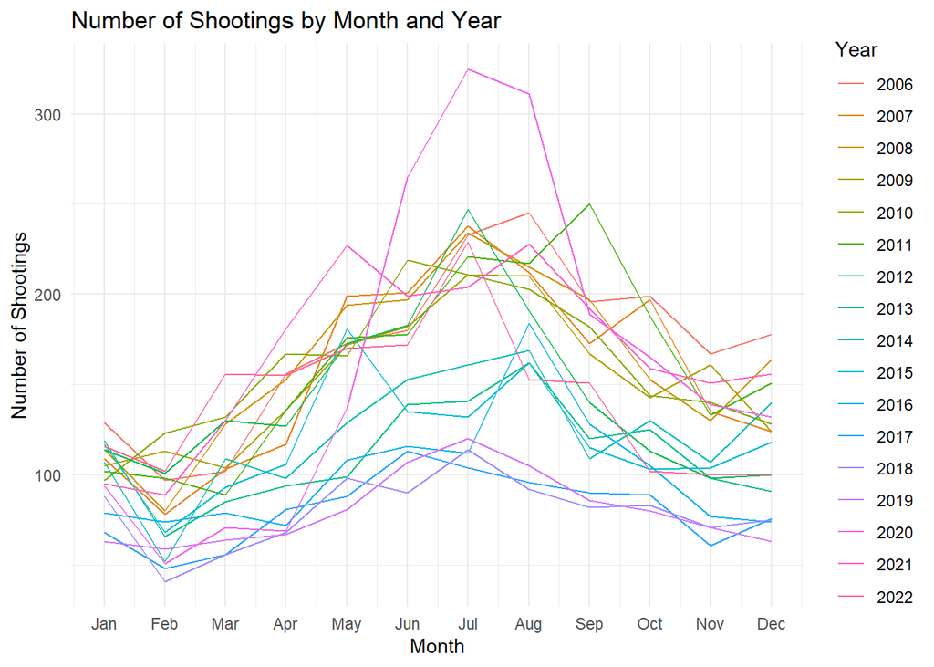

```r
# suppress summarize info
options(dplyr.summarise.inform = FALSE)

# Convert occur_date to date format
nypd <- nypd %>%
  mutate(OCCUR_DATE = mdy(OCCUR_DATE))

# Create a new data frame with counts of shootings per month and year
shooting_counts <- nypd %>%
  group_by(year = year(OCCUR_DATE), month = month(OCCUR_DATE)) %>%
  summarise(shooting_count = n())  # Count the number of shootings per month per year

# Create a line plot for the number of shootings by month and year
ggplot(shooting_counts, aes(x = month, y = shooting_count, group = year, color = factor(year))) +
  geom_line() +
  scale_x_continuous(breaks = 1:12, labels = month.abb) +  # Use month abbreviations on the x-axis
  labs(title = "Number of Shootings by Month and Year",
       x = "Month",
       y = "Number of Shootings",
       color = "Year") +
  theme_minimal()
```

There appears to be a pattern where more shootings occur in the summer. Also, there appears to be a big spike in shootings from June - August of 2020. This makes sense as this coincides with the 2020 Black Lives Matter protests and there was a greatly increased police presense during this period. I will look at the same graph, but only where the victim’s race was black

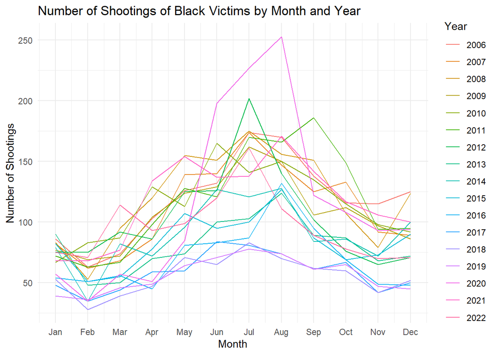

```r
# suppress summarize info
options(dplyr.summarise.inform = FALSE)

# Filter the data for VIC_AGE == "BLACK"
nypd_black_only <- nypd %>%
  filter(VIC_RACE == "BLACK")

# Create a new data frame with counts of shootings per month and year for "BLACK" victims
shooting_counts <- nypd_black_only %>%
  group_by(year = year(OCCUR_DATE), month = month(OCCUR_DATE)) %>%
  summarise(shooting_count = n())  # Count the number of shootings per month per year

# Create a line plot for the number of shootings by month and year for "BLACK" victims
ggplot(shooting_counts, aes(x = month, y = shooting_count, group = year, color = factor(year))) +
  geom_line() +
  scale_x_continuous(breaks = 1:12, labels = month.abb) +  # Use month abbreviations on the x-axis
  labs(title = "Number of Shootings of Black Victims by Month and Year",
       x = "Month",
       y = "Number of Shootings",
       color = "Year") +
  theme_minimal()
```

```r
percentage <- round(length(which(nypd$VIC_RACE == "BLACK")) / nrow(nypd) * 100, digits = 2)
cat("Percentage of shooting victims who were black: ", percentage, "%.")
```

```
## Percentage of shooting victims who were black:  71.18 %.
```

Clearly the majority of shooting victims were black as is evident from the graph and by the percentage. I will create a heatmap of black victims to see if there is a trend on the location.

## Heatmap Visualization

```r
# Select latitude and longitude columns
locations <- nypd_black_only %>% select(Latitude, Longitude)

nyc_map <- leaflet() %>%
  addTiles() %>%
  setView(lng = -74.006, lat = 40.7128, zoom = 10)  # Adjust the center and zoom level as needed

# Add the heatmap layer
nyc_map %>%
  addHeatmap(data = locations, blur = 20, radius = 10)
```

[interactive chart not shown]

Looking at a heatmap of the shootings of black victims, there seems to be a concentration around Brooklyn, Queens, and The Bronx. I decided to create a bar chart by borough.

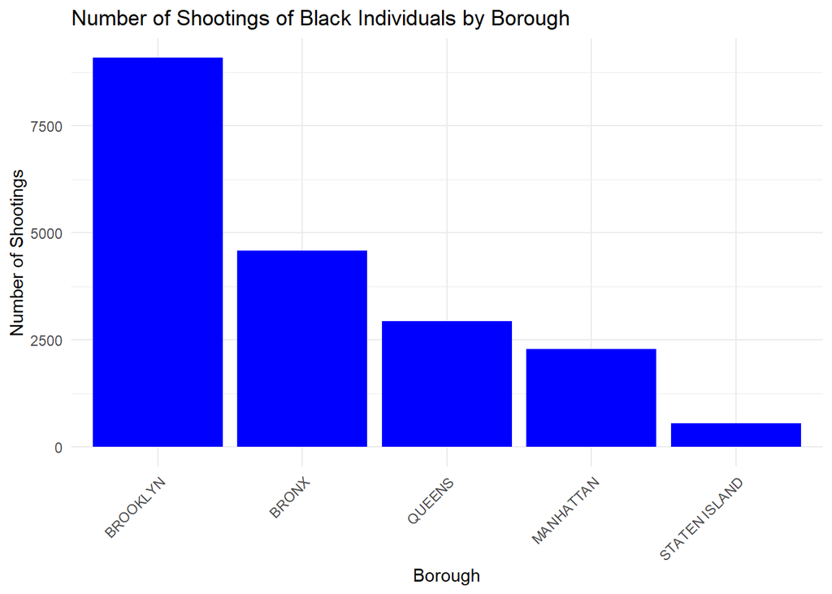

```r
black_shootings_by_borough <- nypd_black_only %>%
  group_by(BORO) %>%
  summarise(shooting_count = n()) %>%
  arrange(desc(shooting_count))  # Sort by shooting count in descending order

ggplot(black_shootings_by_borough, aes(x = reorder(BORO, -shooting_count), y = shooting_count)) +
  geom_bar(stat = "identity", fill = "blue") +
  labs(title = "Number of Shootings of Black Individuals by Borough",
       x = "Borough",
       y = "Number of Shootings") +
  theme_minimal() +
  theme(axis.text.x = element_text(angle = 45, hjust = 1))  # Rotate x-axis labels for better readability
```

## Regression Analysis

I’m curious as to whether black victims are targeted more than other races so I will perform a logistic regression analysis.

```r
# Create a binary target variable indicating 'BLACK' victims
nypd$target_black <- ifelse(nypd$VIC_RACE == "BLACK", 1, 0)

set.seed(123)  # Set a seed for reproducibility
sample_index <- sample.int(nrow(nypd), size = 0.8 * nrow(nypd))  # 80% train, 20% test

train_data <- nypd[sample_index, ]
test_data <- nypd[-sample_index, ]

# Build a logistic regression model
model <- glm(target_black ~ BORO + PRECINCT + JURISDICTION_CODE + STATISTICAL_MURDER_FLAG + VIC_AGE_GROUP + VIC_SEX,
             data = train_data,
             family = "binomial")
```

```r
# Predict using the test dataset
predictions <- predict(model, newdata = test_data, type = "response")

# Convert predicted probabilities to binary predictions
threshold <- 0.5
binary_predictions <- ifelse(predictions > threshold, 1, 0)

# Evaluate model performance
confusion_matrix <- table(test_data$target_black, binary_predictions)
accuracy <- sum(diag(confusion_matrix)) / sum(confusion_matrix)
precision <- confusion_matrix[2, 2] / sum(confusion_matrix[, 2])
recall <- confusion_matrix[2, 2] / sum(confusion_matrix[2, ])
f1_score <- 2 * (precision * recall) / (precision + recall)

# Display performance metrics
print(confusion_matrix)
```

```
##    binary_predictions
##        0    1
##   0   75 1490
##   1   87 3808
```

```r
print(paste("Accuracy:", round(accuracy, 4)))
```

```
## [1] "Accuracy: 0.7112"
```

```r
print(paste("Precision:", round(precision, 4)))
```

```
## [1] "Precision: 0.7188"
```

```r
print(paste("Recall:", round(recall, 4)))
```

```
## [1] "Recall: 0.9777"
```

```r
print(paste("F1 Score:", round(f1_score, 4)))
```

```
## [1] "F1 Score: 0.8285"
```

## Bias Analysis

Analyzing data related to shootings and race carries significant ethical implications and potential biases that need to be carefully considered. Here are some of the key ethical concerns and biases associated with this type of analysis. 1. Racial Bias: If certain demographics are more likely to be targeted or involved in shootings, the model may exhibit demographic bias. For example, over-predicting incidents involving black individuals could be a form of demographic bias. 2. Selection Bias: The data collected by law enforcement agencies may not fully represent all shooting incidents, as there could be underreporting or incomplete reporting, which can introduce selection bias. 3. Personal Bias: As someone who believes that black individuals are targeted by police more than white individuals, I chose not to compare the two races side by side as I might inadvertently try to find a stronger correlation with black shootings than white shootings. 4. Temporal Bias: Patterns in shootings may change over time, and historical data may not fully capture these shifts. Using outdated data may introduce temporal bias.

## Future Work

If I were to come back to this project, something that I would like to do is to research more regression techniques. Since I am still relatively new to the field of data science, there are only so many algorithms and regression techniques that I am familiar with. As my experience in the field continues to grow, my knowledge of machine learning algorithms will also continue to grow and I can approach this problem with potentially better and more optimized algorithms than the ones I chose for this project. I would also like to segment my data by borough or police precinct to see if I get different results. I would also like to compare other US cities to my results from New York City. Additionally, I would like to compare US data to data from other countries to see what the US can do to better prevent gun violence.